# 1. Business Context & Problem Definition

## Business Context

Brain tumors are abnormal growths within brain tissue that can significantly impact neurological function and overall health. Accurate and timely diagnosis is critical for treatment planning and clinical decision-making.

MRI scans are widely used for detecting tumors, but different tumor types (glioma, meningioma, pituitary) may exhibit visually similar patterns. Additionally, scan orientation and image quality can vary.

Manual interpretation is:

- Time-consuming
- Subject to inter-observer variability
- Prone to misclassification

Therefore, an automated deep learning solution can support consistent and reliable classification of MRI brain scans.

# Objective

The objectives of this project are to:

- Classify MRI images into four categories:
  - Glioma
  - Meningioma
  - Pituitary Tumor
  - No Tumor (Healthy)
- Compare Artificial Neural Networks (ANN) vs Convolutional Neural Networks (CNN)
- Evaluate the impact of:
  - Model optimization
  - Transfer learning
  - Fine-tuning
  - Data augmentation
- Select the best-performing model based on validation and test macro-F1 score

## Project Workflow Summary

This project follows a complete deep learning workflow:

1. Inspect and organize a four-class MRI image dataset.
2. Apply preprocessing steps to standardize image size, remove border artifacts, and normalize pixel values.
3. Train multiple neural network models, beginning with ANN baselines and progressing to CNN-based transfer learning.
4. Compare models using validation macro-F1 score and final test performance.
5. Select the best model based on generalization performance, interpretability of results, and suitability for medical imaging classification.

The project emphasizes both technical model performance and practical concerns such as dataset quality, artifact risk, and class-level evaluation.

# 2. Data Overview

### Dataset Structure

The dataset contains 2,895 MRI images distributed across four classes:

### Glioma : 645

### Meningioma : 660

### Pituitary : 750

### No Tumor : 840

The dataset is moderately balanced, making macro-F1 an appropriate evaluation metric.

```python
import os, random, math
from pathlib import Path
import numpy as np
import pandas as pd
import matplotlib.pyplot as plt

import torch
import torch.nn as nn
from torch.utils.data import Dataset, DataLoader
from torchvision import transforms
from torchvision.models import vgg16, VGG16_Weights
from PIL import Image

from sklearn.model_selection import train_test_split
from sklearn.metrics import f1_score, confusion_matrix, classification_report

SEED = 42
random.seed(SEED)
np.random.seed(SEED)
torch.manual_seed(SEED)
torch.cuda.manual_seed_all(SEED)

DEVICE = "cuda" if torch.cuda.is_available() else "cpu"

DATA_DIR = Path(r"c:\Users\13015\Desktop\dataset")
CLASS_NAMES = ["glioma", "meningioma", "pituitary", "notumor"]
CLASS_TO_IDX = {c:i for i,c in enumerate(CLASS_NAMES)}
IDX_TO_CLASS = {v:k for k,v in CLASS_TO_IDX.items()}

IMG_SIZE = 224
CROP_MARGIN = 12
BATCH_SIZE = 32
NUM_WORKERS = 2
```

```python
def build_index(data_dir: Path, class_names):
    rows = []
    for cls in class_names:
        cls_dir = data_dir / cls
        if not cls_dir.exists():
            raise FileNotFoundError(f"Missing class folder: {cls_dir}")
        for fp in cls_dir.rglob("*"):
            if fp.suffix.lower() in [".jpg", ".jpeg", ".png", ".bmp"]:
                rows.append({"filepath": str(fp), "label": cls, "y": CLASS_TO_IDX[cls]})
    df = pd.DataFrame(rows)
    return df

df = build_index(DATA_DIR, CLASS_NAMES)

print("Total images:", len(df))
print(df["label"].value_counts())
df.head()

train_df, temp_df = train_test_split(
    df, test_size=0.30, stratify=df["y"], random_state=SEED
)

val_df, test_df = train_test_split(
    temp_df, test_size=0.50, stratify=temp_df["y"], random_state=SEED
)

print("Train:", len(train_df), train_df["label"].value_counts().to_dict())
print("Val:", len(val_df), val_df["label"].value_counts().to_dict())
print("Test:", len(test_df), test_df["label"].value_counts().to_dict())
```

```
Total images: 2895
label
notumor       840
pituitary     750
meningioma    660
glioma        645
Name: count, dtype: int64
Train: 2026 {'notumor': 588, 'pituitary': 525, 'meningioma': 462, 'glioma': 451}
Val: 434 {'notumor': 126, 'pituitary': 112, 'meningioma': 99, 'glioma': 97}
Test: 435 {'notumor': 126, 'pituitary': 113, 'meningioma': 99, 'glioma': 97}
```

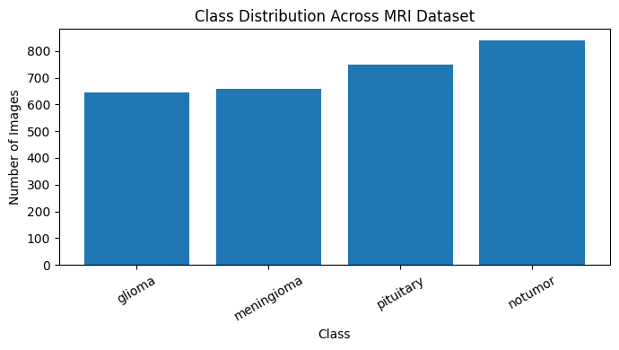

|  | Class | Image Count | Percentage |
| --- | --- | --- | --- |
| 0 | glioma | 645 | 22.28 |
| 1 | meningioma | 660 | 22.80 |
| 2 | pituitary | 750 | 25.91 |
| 3 | notumor | 840 | 29.02 |

```python
class_counts = df["label"].value_counts().reindex(CLASS_NAMES)

plt.figure(figsize=(7, 4))
plt.bar(class_counts.index, class_counts.values)
plt.title("Class Distribution Across MRI Dataset")
plt.xlabel("Class")
plt.ylabel("Number of Images")
plt.xticks(rotation=30)
plt.tight_layout()
plt.show()

class_summary = pd.DataFrame({
    "Class": class_counts.index,
    "Image Count": class_counts.values,
    "Percentage": (class_counts.values / class_counts.values.sum() * 100).round(2)
})

class_summary
```

## Class Distribution Interpretation

The dataset contains four MRI image categories: glioma, meningioma, pituitary tumor, and no tumor. The class distribution is moderately balanced, with the no-tumor class containing the highest number of images and glioma containing the fewest.

Because the dataset is not perfectly balanced, macro-F1 score is used as a primary evaluation metric. Macro-F1 treats each class equally and provides a better measure of performance across all tumor categories than accuracy alone.

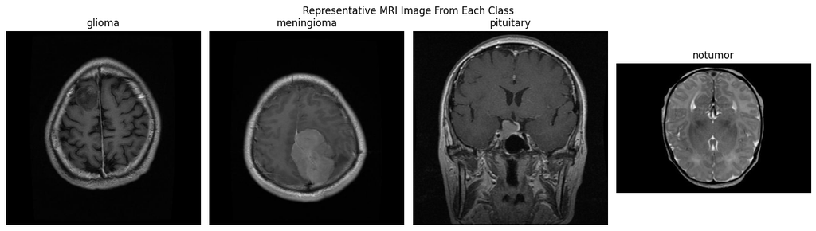

```python
def show_one_sample_per_class(df, class_names):
    fig, axes = plt.subplots(1, len(class_names), figsize=(14, 4))

    for ax, cls in zip(axes, class_names):
        sample_path = df[df["label"] == cls].sample(1, random_state=SEED)["filepath"].iloc[0]
        img = Image.open(sample_path).convert("RGB")

        ax.imshow(img)
        ax.set_title(cls)
        ax.axis("off")

    plt.suptitle("Representative MRI Image From Each Class")
    plt.tight_layout()
    plt.show()

show_one_sample_per_class(df, CLASS_NAMES)
```

## Sample Image Overview

Representative images from each class show that the dataset contains meaningful visual differences between tumor and non-tumor scans. However, several challenges are also visible, including differences in scan orientation, brightness, cropping, and image quality.

These visual differences support the use of convolutional neural networks, which are better suited than flattened ANN models for learning spatial patterns in image data.

# Data Inspection

- Images vary in anatomical plane (axial, sagittal, coronal).
- Minor artifacts are present in some images.
- Brightness and intensity vary across scans.

This variability supports the need for:

- Proper normalization
- CNN-based spatial learning
- Potential data augmentation

# 3. Exploratory Data Analysis (EDA)

## Image Dimensions

MRI scans exhibit variability in:

- Resolution
- Aspect ratio
- Cropping margins

Images are resized to 224×224 for CNN training.

# Dataset Bias & Artifact Risk Analysis

- During dataset inspection we can see several images contain watermark and metadata artifacts located near the image borders. To prevent the model from learning spurious correlations, a uniform border crop was applied to all images prior to resizing.
- Some scans exhibit motion blur or acquisition artifacts. Because these are not label-specific and occur across scans, we treat them as natural variability and use augmentation and standardized preprocessing to build robustness

```python
class BrainMRIDataset(Dataset):
    def __init__(self, df: pd.DataFrame, transform=None):
        self.df = df.reset_index(drop=True)
        self.transform = transform

    def __len__(self):
        return len(self.df)

    def __getitem__(self, idx):
        row = self.df.iloc[idx]
        img = Image.open(row["filepath"]).convert("RGB")
        y = int(row["y"])
        if self.transform:
            img = self.transform(img)
        return img, y

def border_crop_pil(img: Image.Image, margin: int):
    w, h = img.size
    return img.crop((margin, margin, w - margin, h - margin))

base_transform = transforms.Compose([
    transforms.Lambda(lambda im: border_crop_pil(im, CROP_MARGIN)),
    transforms.Resize((IMG_SIZE, IMG_SIZE)),
    transforms.ToTensor(),                     # [0,1]
    # For VGG16 pretrained weights, use ImageNet normalization:
    transforms.Normalize(mean=[0.485,0.456,0.406], std=[0.229,0.224,0.225]),
])

aug_transform = transforms.Compose([
    transforms.Lambda(lambda im: border_crop_pil(im, CROP_MARGIN)),
    transforms.Resize((IMG_SIZE, IMG_SIZE)),
    transforms.RandomRotation(15),
    transforms.RandomResizedCrop(IMG_SIZE, scale=(0.90, 1.00)),
    transforms.RandomHorizontalFlip(p=0.5),
    transforms.ToTensor(),
    transforms.Normalize(mean=[0.485,0.456,0.406], std=[0.229,0.224,0.225]),
])
```

```python
train_ds = BrainMRIDataset(train_df, transform=base_transform)
val_ds   = BrainMRIDataset(val_df, transform=base_transform)
test_ds  = BrainMRIDataset(test_df, transform=base_transform)

train_loader = DataLoader(train_ds, batch_size=BATCH_SIZE, shuffle=True,
                          num_workers=NUM_WORKERS, pin_memory=True)
val_loader   = DataLoader(val_ds, batch_size=BATCH_SIZE, shuffle=False,
                          num_workers=NUM_WORKERS, pin_memory=True)
test_loader  = DataLoader(test_ds, batch_size=BATCH_SIZE, shuffle=False,
                          num_workers=NUM_WORKERS, pin_memory=True)
```

## Visual Inspection of Raw MRI Images

Before modeling, raw images are inspected to understand variation across classes. This step helps identify potential issues such as inconsistent image orientation, brightness differences, artifacts, and border markings.

Visual inspection is especially important in medical image classification because a model may accidentally learn non-medical artifacts if they are correlated with a class label.

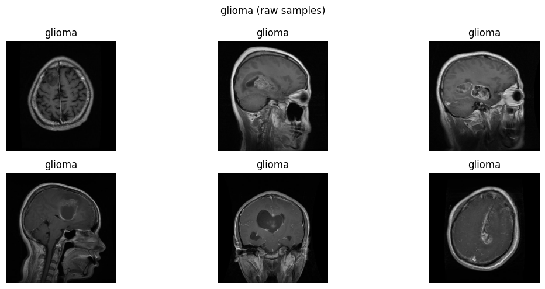

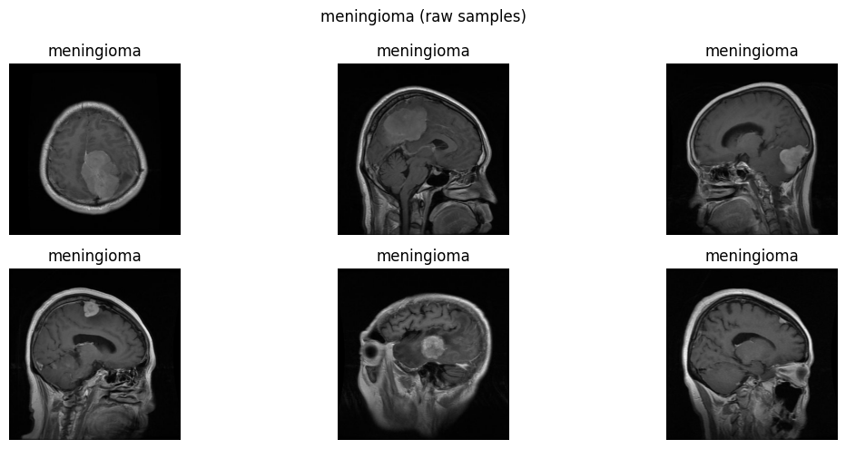

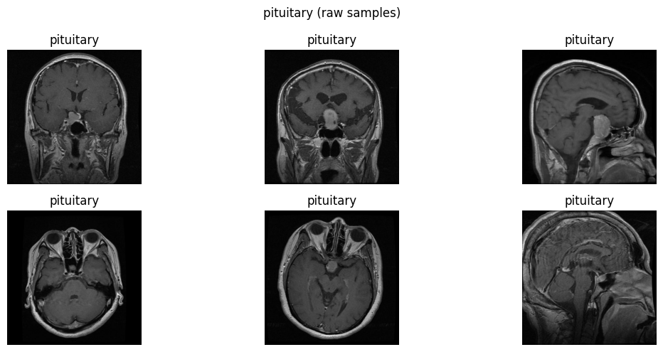

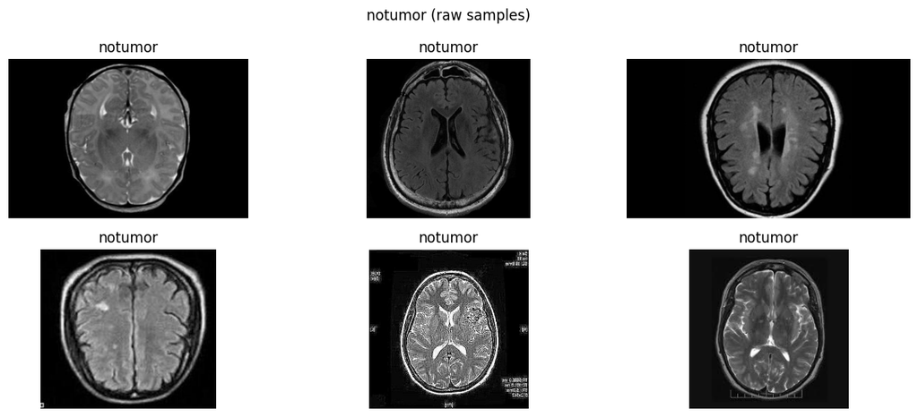

```python
def show_samples(df_subset, n=8, title="Samples"):
    sample = df_subset.sample(n=min(n, len(df_subset)), random_state=SEED)
    fig, axes = plt.subplots(2, math.ceil(n/2), figsize=(12,5))
    axes = axes.ravel()
    for ax, (_, r) in zip(axes, sample.iterrows()):
        img = Image.open(r["filepath"]).convert("RGB")
        ax.imshow(img, cmap="gray")
        ax.set_title(r["label"])
        ax.axis("off")
    plt.suptitle(title)
    plt.tight_layout()
    plt.show()

for cls in CLASS_NAMES:
    show_samples(df[df["label"]==cls], n=6, title=f"{cls} (raw samples)")
```

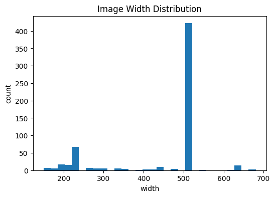

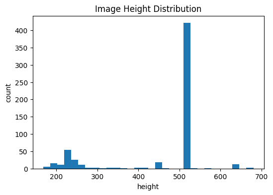

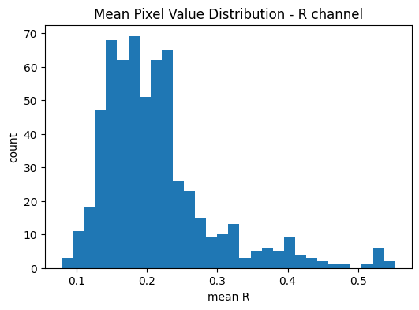

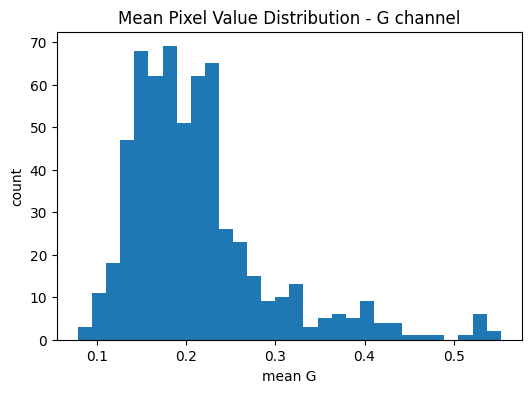

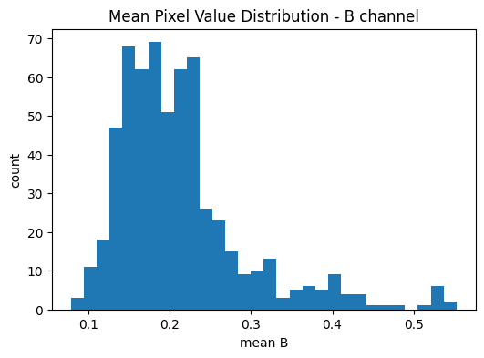

```python
def get_image_sizes(sample_df, max_n=400):
    samp = sample_df.sample(n=min(max_n, len(sample_df)), random_state=SEED)
    widths, heights = [], []
    for fp in samp["filepath"]:
        img = Image.open(fp)
        w,h = img.size
        widths.append(w); heights.append(h)
    return np.array(widths), np.array(heights)

w, h = get_image_sizes(df, max_n=600)

plt.figure(figsize=(6,4))
plt.hist(w, bins=30)
plt.title("Image Width Distribution")
plt.xlabel("width"); plt.ylabel("count")
plt.show()

plt.figure(figsize=(6,4))
plt.hist(h, bins=30)
plt.title("Image Height Distribution")
plt.xlabel("height"); plt.ylabel("count")
plt.show()

raw_tensor_transform = transforms.Compose([
    transforms.Lambda(lambda im: border_crop_pil(im, CROP_MARGIN)),
    transforms.Resize((IMG_SIZE, IMG_SIZE)),
    transforms.ToTensor(),  # [0,1]
])

def mean_rgb_distribution(sample_df, max_n=400):
    samp = sample_df.sample(n=min(max_n, len(sample_df)), random_state=SEED)
    means = []
    for fp in samp["filepath"]:
        img = Image.open(fp).convert("RGB")
        t = raw_tensor_transform(img)  # (3,H,W)
        means.append(t.view(3,-1).mean(dim=1).numpy())
    means = np.vstack(means)
    return means

means = mean_rgb_distribution(df, max_n=600)  # shape (N,3)

plt.figure(figsize=(6,4))
plt.hist(means[:,0], bins=30)
plt.title("Mean Pixel Value Distribution - R channel")
plt.xlabel("mean R"); plt.ylabel("count")
plt.show()

plt.figure(figsize=(6,4))
plt.hist(means[:,1], bins=30)
plt.title("Mean Pixel Value Distribution - G channel")
plt.xlabel("mean G"); plt.ylabel("count")
plt.show()

plt.figure(figsize=(6,4))
plt.hist(means[:,2], bins=30)
plt.title("Mean Pixel Value Distribution - B channel")
plt.xlabel("mean B"); plt.ylabel("count")
plt.show()
```

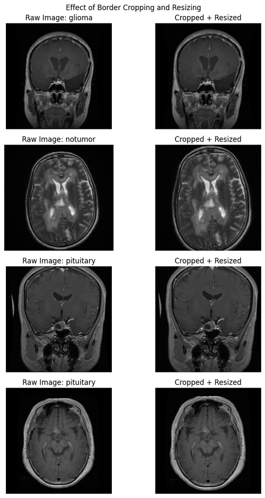

```python
def show_preprocessing_effect(df_subset, n=4):
    sample = df_subset.sample(n=min(n, len(df_subset)), random_state=SEED)

    fig, axes = plt.subplots(n, 2, figsize=(8, 3 * n))

    for i, (_, row) in enumerate(sample.iterrows()):
        raw_img = Image.open(row["filepath"]).convert("RGB")
        cropped_img = border_crop_pil(raw_img, CROP_MARGIN).resize((IMG_SIZE, IMG_SIZE))

        axes[i, 0].imshow(raw_img)
        axes[i, 0].set_title(f"Raw Image: {row['label']}")
        axes[i, 0].axis("off")

        axes[i, 1].imshow(cropped_img)
        axes[i, 1].set_title("Cropped + Resized")
        axes[i, 1].axis("off")

    plt.suptitle("Effect of Border Cropping and Resizing")
    plt.tight_layout()
    plt.show()

show_preprocessing_effect(df, n=4)
```

## Preprocessing Effect

The preprocessing step applies a consistent border crop and resize operation to every image. The border crop helps reduce the risk that the model will learn from image-frame artifacts, labels, or scanner overlays rather than anatomical features.

Resizing all images to a fixed 224×224 format also ensures compatibility with VGG16, which expects standardized image dimensions.

# Pixel Distribution

We examine:

- Mean RGB channel intensities
- Intensity normalization

Normalization is applied using ImageNet statistics to align with pretrained VGG16 expectations.

# 4. Data Preprocessing

## Preprocessing Steps

- Border cropping (to remove artifacts in black margins)
- Resize to 224×224
- Conversion to tensor
- Normalization
- Stratified train/validation/test split

Split ratio:

- 70% Train
- 15% Validation
- 15% Test

## Train, Validation, and Test Strategy

The dataset is split into training, validation, and test sets using stratified sampling. Stratification preserves the original class distribution across each split, reducing the risk that one class becomes underrepresented during training or evaluation.

The validation set is used to compare models and select the best-performing configuration. The test set is reserved for final evaluation only, providing a more realistic estimate of how the selected model performs on unseen data.

```python
split_summary = pd.DataFrame({
    "Split": ["Train", "Validation", "Test"],
    "Images": [len(train_df), len(val_df), len(test_df)],
    "Percentage": [
        round(len(train_df) / len(df) * 100, 2),
        round(len(val_df) / len(df) * 100, 2),
        round(len(test_df) / len(df) * 100, 2)
    ]
})

split_summary
```

|  | Split | Images | Percentage |
| --- | --- | --- | --- |
| 0 | Train | 2026 | 69.98 |
| 1 | Validation | 434 | 14.99 |
| 2 | Test | 435 | 15.03 |

## Split Summary Interpretation

The final dataset split follows a 70/15/15 structure. The training set is used for model learning, the validation set supports model comparison and checkpoint selection, and the test set is held out for final unbiased evaluation.

This separation helps prevent overfitting model decisions to the final test data.

```python
def run_epoch(model, loader, criterion, optimizer=None):
    train = optimizer is not None
    model.train(train)

    all_y, all_pred = [], []
    total_loss = 0.0
    total = 0

    for x, y in loader:
        x, y = x.to(DEVICE), y.to(DEVICE)

        if train:
            optimizer.zero_grad()

        logits = model(x)
        loss = criterion(logits, y)

        if train:
            loss.backward()
            optimizer.step()

        total_loss += loss.item() * y.size(0)
        total += y.size(0)

        preds = torch.argmax(logits, dim=1)
        all_y.append(y.detach().cpu().numpy())
        all_pred.append(preds.detach().cpu().numpy())

    all_y = np.concatenate(all_y)
    all_pred = np.concatenate(all_pred)

    acc = (all_pred == all_y).mean()
    macro_f1 = f1_score(all_y, all_pred, average="macro")
    return total_loss / total, acc, macro_f1

def train_model(model, train_loader, val_loader, epochs=10, lr=1e-3, weight_decay=0.0):
    model.to(DEVICE)
    criterion = nn.CrossEntropyLoss()
    optimizer = torch.optim.Adam(model.parameters(), lr=lr, weight_decay=weight_decay)

    best_val_f1 = -1
    best_state = None
    history = []

    for ep in range(1, epochs+1):
        tr_loss, tr_acc, tr_f1 = run_epoch(model, train_loader, criterion, optimizer)
        va_loss, va_acc, va_f1 = run_epoch(model, val_loader, criterion, optimizer=None)

        history.append((ep, tr_loss, tr_acc, tr_f1, va_loss, va_acc, va_f1))
        print(f"Epoch {ep:02d} | "
              f"train loss {tr_loss:.4f} acc {tr_acc:.3f} f1 {tr_f1:.3f} | "
              f"val loss {va_loss:.4f} acc {va_acc:.3f} f1 {va_f1:.3f}")

        if va_f1 > best_val_f1:
            best_val_f1 = va_f1
            best_state = {k: v.detach().cpu().clone() for k,v in model.state_dict().items()}

    if best_state is not None:
        model.load_state_dict(best_state)
    return model, pd.DataFrame(history, columns=["epoch","tr_loss","tr_acc","tr_f1","va_loss","va_acc","va_f1"])
```

```python
from torch.utils.data import Dataset, DataLoader

class BrainMRIDataset(Dataset):
    ...

from torchvision import transforms
from PIL import Image

IMG_SIZE = 224
CROP_MARGIN = 12

def border_crop_pil(img: Image.Image, margin: int):
    w, h = img.size
    return img.crop((margin, margin, w - margin, h - margin))

base_transform = transforms.Compose([
    transforms.Lambda(lambda im: border_crop_pil(im, CROP_MARGIN)),
    transforms.Resize((IMG_SIZE, IMG_SIZE)),
    transforms.ToTensor(),
    transforms.Normalize(mean=[0.485,0.456,0.406], std=[0.229,0.224,0.225]),
])
```

```python
df = build_index(DATA_DIR, CLASS_NAMES)
```

```python
from sklearn.model_selection import train_test_split


train_df, temp_df = train_test_split(
    df,
    test_size=0.30,
    stratify=df["y"],
    random_state=SEED
)

val_df, test_df = train_test_split(
    temp_df,
    test_size=0.50,
    stratify=temp_df["y"],
    random_state=SEED
)

print("Train:", len(train_df), train_df["label"].value_counts().to_dict())
print("Val:  ", len(val_df),   val_df["label"].value_counts().to_dict())
print("Test: ", len(test_df),  test_df["label"].value_counts().to_dict())
```

```
Train: 2026 {'notumor': 588, 'pituitary': 525, 'meningioma': 462, 'glioma': 451}
Val:   434 {'notumor': 126, 'pituitary': 112, 'meningioma': 99, 'glioma': 97}
Test:  435 {'notumor': 126, 'pituitary': 113, 'meningioma': 99, 'glioma': 97}
```

```python
print(df.shape)
print(df.columns)
print(df["y"].value_counts())
```

```
(2895, 3)
Index(['filepath', 'label', 'y'], dtype='object')
y
3    840
2    750
1    660
0    645
Name: count, dtype: int64
```

```python
from torch.utils.data import Dataset
from PIL import Image

class BrainMRIDataset(Dataset):
    def __init__(self, df, transform=None):
        self.df = df.reset_index(drop=True)
        self.transform = transform

    def __len__(self):
        return len(self.df)

    def __getitem__(self, idx):
        row = self.df.iloc[idx]
        img = Image.open(row["filepath"]).convert("RGB")
        y = int(row["y"])
        if self.transform:
            img = self.transform(img)
        return img, y
```

```python
train_ds = BrainMRIDataset(train_df, transform=base_transform)
val_ds   = BrainMRIDataset(val_df, transform=base_transform)
test_ds  = BrainMRIDataset(test_df, transform=base_transform)
```

```python
NUM_WORKERS = 0

train_loader = DataLoader(
    train_ds,
    batch_size=BATCH_SIZE,
    shuffle=True,
    num_workers=NUM_WORKERS,
    pin_memory=False
)

val_loader = DataLoader(
    val_ds,
    batch_size=BATCH_SIZE,
    shuffle=False,
    num_workers=NUM_WORKERS,
    pin_memory=False
)
```

```python
print("train:", len(train_ds), "val:", len(val_ds), "test:", len(test_ds))
```

```
train: 2026 val: 434 test: 435
```

```python
x, y = train_ds[0]
print(type(x), x.shape, y, IDX_TO_CLASS[y])
```

```
<class 'torch.Tensor'> torch.Size([3, 224, 224]) 0 glioma
```

```python
from torch.utils.data import DataLoader

NUM_WORKERS = 0  # keep this for Windows stability
train_loader = DataLoader(train_ds, batch_size=BATCH_SIZE, shuffle=True, num_workers=NUM_WORKERS, pin_memory=False)

xb, yb = next(iter(train_loader))
print(xb.shape, yb.shape, yb[:10].tolist())
```

```
torch.Size([32, 3, 224, 224]) torch.Size([32]) [2, 2, 1, 1, 3, 2, 1, 1, 2, 0]
```

```python
ANN_SIZE = 64

ann_transform = transforms.Compose([
    transforms.Lambda(lambda im: border_crop_pil(im, CROP_MARGIN)),
    transforms.Resize((ANN_SIZE, ANN_SIZE)),
    transforms.ToTensor(),
])

train_ds_ann = BrainMRIDataset(train_df, transform=ann_transform)
val_ds_ann   = BrainMRIDataset(val_df, transform=ann_transform)

train_loader_ann = DataLoader(train_ds_ann, batch_size=64, shuffle=True, num_workers=0, pin_memory=False)
val_loader_ann   = DataLoader(val_ds_ann, batch_size=64, shuffle=False, num_workers=0, pin_memory=False)

# sanity check
xb, yb = next(iter(train_loader_ann))
print(xb.shape, yb.shape)
```

```
torch.Size([64, 3, 64, 64]) torch.Size([64])
```

# 5. Model 1 – Baseline ANN

## Rationale

The ANN uses a flattened 1D image representation.

Limitation:

- Loses spatial structure
- Cannot explicitly learn edges or tumor location

## Baseline Model Purpose

The baseline ANN provides a simple comparison point for later CNN models. Since the ANN flattens each image into a one-dimensional vector, it does not preserve the spatial relationships between pixels.

This model is useful because it shows what performance can be achieved without convolutional feature extraction.

```python
class SimpleANN(nn.Module):
    def __init__(self, num_classes=4):
        super().__init__()
        in_features = ANN_SIZE * ANN_SIZE * 3
        self.net = nn.Sequential(
            nn.Flatten(),
            nn.Linear(in_features, 256),
            nn.ReLU(),
            nn.Linear(256, 128),
            nn.ReLU(),
            nn.Linear(128, num_classes),
        )
    def forward(self, x):
        return self.net(x)

ann1 = SimpleANN(num_classes=4)
ann1, hist_ann1 = train_model(ann1, train_loader_ann, val_loader_ann, epochs=10, lr=1e-3)
```

```
Epoch 01 | train loss 1.0179 acc 0.523 f1 0.497 | val loss 0.7326 acc 0.668 f1 0.619
Epoch 02 | train loss 0.6937 acc 0.703 f1 0.679 | val loss 0.6331 acc 0.710 f1 0.648
Epoch 03 | train loss 0.5634 acc 0.758 f1 0.740 | val loss 0.6888 acc 0.677 f1 0.598
Epoch 04 | train loss 0.4982 acc 0.787 f1 0.769 | val loss 0.5649 acc 0.742 f1 0.698
Epoch 05 | train loss 0.4289 acc 0.812 f1 0.796 | val loss 0.4399 acc 0.818 f1 0.801
Epoch 06 | train loss 0.4275 acc 0.817 f1 0.804 | val loss 0.4337 acc 0.813 f1 0.800
Epoch 07 | train loss 0.4034 acc 0.815 f1 0.800 | val loss 0.4511 acc 0.811 f1 0.791
Epoch 08 | train loss 0.3054 acc 0.887 f1 0.877 | val loss 0.4338 acc 0.804 f1 0.780
Epoch 09 | train loss 0.2712 acc 0.888 f1 0.878 | val loss 0.3643 acc 0.857 f1 0.843
Epoch 10 | train loss 0.2580 acc 0.894 f1 0.884 | val loss 0.3772 acc 0.853 f1 0.838
```

## Baseline ANN Interpretation

The baseline ANN achieved reasonable performance, but its limitations are expected for image classification. Flattening the MRI scans removes spatial information such as tumor location, edge boundaries, texture patterns, and shape relationships.

The result confirms that a more image-aware architecture is needed for this task.

# Results

Observation:

- Moderate overfitting
- Limited ability to distinguish spatially similar tumor types

### Conclusion:

Spatial information is important for this task.

# 6. Model 2 – Optimized ANN

### Improvements Applied

- Increased network depth
- Batch Normalization
- Dropout regularization
- Weight decay

## Optimized ANN Purpose

The optimized ANN tests whether stronger regularization and a deeper architecture can improve performance without changing the fundamental model type.

Batch normalization helps stabilize training, dropout reduces overfitting, and weight decay discourages overly complex parameter weights.

```python
class OptimizedANN(nn.Module):
    def __init__(self, num_classes=4):
        super().__init__()
        in_features = ANN_SIZE * ANN_SIZE * 3
        self.net = nn.Sequential(
            nn.Flatten(),
            nn.Linear(in_features, 512),
            nn.BatchNorm1d(512),
            nn.ReLU(),
            nn.Dropout(0.4),

            nn.Linear(512, 256),
            nn.BatchNorm1d(256),
            nn.ReLU(),
            nn.Dropout(0.3),

            nn.Linear(256, num_classes),
        )

    def forward(self, x):
        return self.net(x)

ann2 = OptimizedANN(num_classes=4)
ann2, hist_ann2 = train_model(
    ann2,
    train_loader_ann,
    val_loader_ann,
    epochs=15,
    lr=8e-4,
    weight_decay=1e-4
)
```

```
Epoch 01 | train loss 0.7360 acc 0.703 f1 0.688 | val loss 0.5579 acc 0.760 f1 0.742
Epoch 02 | train loss 0.4511 acc 0.828 f1 0.816 | val loss 0.5000 acc 0.795 f1 0.791
Epoch 03 | train loss 0.3100 acc 0.882 f1 0.872 | val loss 0.3648 acc 0.857 f1 0.850
Epoch 04 | train loss 0.2369 acc 0.913 f1 0.906 | val loss 0.4237 acc 0.843 f1 0.825
Epoch 05 | train loss 0.1813 acc 0.935 f1 0.931 | val loss 0.4039 acc 0.853 f1 0.846
Epoch 06 | train loss 0.1677 acc 0.942 f1 0.937 | val loss 0.3296 acc 0.876 f1 0.866
Epoch 07 | train loss 0.1250 acc 0.958 f1 0.954 | val loss 0.3023 acc 0.882 f1 0.874
Epoch 08 | train loss 0.1263 acc 0.955 f1 0.951 | val loss 0.3897 acc 0.859 f1 0.848
Epoch 09 | train loss 0.1161 acc 0.964 f1 0.961 | val loss 0.3353 acc 0.882 f1 0.872
Epoch 10 | train loss 0.1114 acc 0.962 f1 0.959 | val loss 0.5714 acc 0.825 f1 0.804
Epoch 11 | train loss 0.0994 acc 0.967 f1 0.964 | val loss 0.4486 acc 0.850 f1 0.837
Epoch 12 | train loss 0.0881 acc 0.964 f1 0.962 | val loss 0.3289 acc 0.887 f1 0.879
Epoch 13 | train loss 0.0926 acc 0.972 f1 0.971 | val loss 0.4371 acc 0.864 f1 0.850
Epoch 14 | train loss 0.0646 acc 0.978 f1 0.976 | val loss 0.3819 acc 0.878 f1 0.870
Epoch 15 | train loss 0.0535 acc 0.982 f1 0.980 | val loss 0.7158 acc 0.825 f1 0.804
```

## Optimized ANN Interpretation

The optimized ANN improved over the baseline ANN, showing that regularization and architecture tuning helped the model generalize better.

However, the model still depends on flattened image inputs. This means it remains limited compared with CNN models that can directly learn spatial features from MRI scans.

# Results:

Improvement demonstrates:

- Regularization enhances generalization
- But flattened representation remains limiting

# 7. Model 3 – VGG16 (Frozen Base)

### Rationale

CNNs preserve spatial structure.

Transfer learning:

- Uses pretrained feature detectors
- Reduces training time
- Improves performance on limited datasets

## Transfer Learning Rationale

VGG16 is a pretrained convolutional neural network originally trained on a large-scale image dataset. Although MRI scans differ from natural images, the early convolutional layers can still provide useful low-level feature detectors such as edges, textures, and shapes.

Freezing the convolutional base allows the project to test whether pretrained features alone are useful for MRI classification.

```python
train_ds = BrainMRIDataset(train_df, transform=base_transform)
val_ds   = BrainMRIDataset(val_df, transform=base_transform)
test_ds  = BrainMRIDataset(test_df, transform=base_transform)

NUM_WORKERS = 0
train_loader = DataLoader(train_ds, batch_size=BATCH_SIZE, shuffle=True,  num_workers=NUM_WORKERS, pin_memory=False)
val_loader   = DataLoader(val_ds,   batch_size=BATCH_SIZE, shuffle=False, num_workers=NUM_WORKERS, pin_memory=False)
test_loader  = DataLoader(test_ds,  batch_size=BATCH_SIZE, shuffle=False, num_workers=NUM_WORKERS, pin_memory=False)


xb, yb = next(iter(train_loader))
print(xb.shape, yb.shape)
```

```
torch.Size([32, 3, 224, 224]) torch.Size([32])
```

```python
from torchvision.models import vgg16, VGG16_Weights

def make_vgg16_frozen(num_classes=4):
    weights = VGG16_Weights.DEFAULT
    model = vgg16(weights=weights)


    for p in model.features.parameters():
        p.requires_grad = False


    model.classifier[6] = nn.Linear(4096, num_classes)
    return model

vgg3 = make_vgg16_frozen(num_classes=4).to(DEVICE)


print("Trainable params:", sum(p.requires_grad for p in vgg3.parameters()))
```

```
Trainable params: 6
```

```python
total_params = sum(p.numel() for p in vgg3.parameters())
trainable_params = sum(p.numel() for p in vgg3.parameters() if p.requires_grad)

pd.DataFrame({
    "Model": ["VGG16 Frozen Base"],
    "Total Parameters": [total_params],
    "Trainable Parameters": [trainable_params],
    "Frozen Parameters": [total_params - trainable_params]
})
```

|  | Model | Total Parameters | Trainable Parameters | Frozen Parameters |
| --- | --- | --- | --- | --- |
| 0 | VGG16 Frozen Base | 134276932 | 119562244 | 14714688 |

## Frozen Model Parameter Interpretation

This approach reduces training time and overfitting risk, but it may limit performance because the feature extractor cannot fully adapt to MRI-specific patterns.

```python
vgg3, hist_vgg3 = train_model(
    vgg3,
    train_loader,
    val_loader,
    epochs=8,
    lr=1e-3,
    weight_decay=1e-4
)
```

```
Epoch 01 | train loss 0.8091 acc 0.778 f1 0.764 | val loss 0.3660 acc 0.889 f1 0.878
Epoch 02 | train loss 0.3481 acc 0.913 f1 0.905 | val loss 0.6017 acc 0.882 f1 0.871
Epoch 03 | train loss 0.4621 acc 0.917 f1 0.911 | val loss 0.5522 acc 0.880 f1 0.865
Epoch 04 | train loss 0.3555 acc 0.941 f1 0.936 | val loss 0.5128 acc 0.901 f1 0.889
Epoch 05 | train loss 0.2787 acc 0.949 f1 0.945 | val loss 0.5918 acc 0.910 f1 0.898
Epoch 06 | train loss 0.2128 acc 0.961 f1 0.957 | val loss 0.5753 acc 0.924 f1 0.915
Epoch 07 | train loss 0.2057 acc 0.971 f1 0.969 | val loss 0.6647 acc 0.926 f1 0.919
Epoch 08 | train loss 0.2697 acc 0.967 f1 0.965 | val loss 1.7106 acc 0.880 f1 0.868
```

# Results:

### Observation:

Validation performance peaked around epoch 7; later epochs showed signs of overfitting. Early stopping / best-checkpoint selection was used by choosing the best validation macro-F1.

# 8. Model 4 – VGG16 (Feedforward Head + Fine-Tuning)

### Modifications

- Replaced classifier with deeper head (1024 → 256 → 4)
- Fine-tuned last convolutional block
- Lower learning rate for fine-tuning

## Fine-Tuning Rationale

Fine-tuning allows selected pretrained convolutional layers to update during training. This gives the model the ability to adapt general visual features to MRI-specific structures while still benefiting from transfer learning.

Only the later convolutional layers are fine-tuned because earlier layers usually capture more general patterns such as edges and simple textures.

# Model 4A

```python
from torchvision.models import vgg16, VGG16_Weights

def make_vgg16_ff_head(num_classes=4):
    weights = VGG16_Weights.DEFAULT
    model = vgg16(weights=weights)


    for p in model.features.parameters():
        p.requires_grad = False


    model.classifier = nn.Sequential(
        nn.Linear(25088, 1024),
        nn.ReLU(),
        nn.Dropout(0.4),
        nn.Linear(1024, 256),
        nn.ReLU(),
        nn.Dropout(0.3),
        nn.Linear(256, num_classes)
    )
    return model

vgg4 = make_vgg16_ff_head(num_classes=4).to(DEVICE)

vgg4, hist_vgg4a = train_model(
    vgg4,
    train_loader,
    val_loader,
    epochs=8,
    lr=1e-3,
    weight_decay=1e-4
)
```

```
Epoch 01 | train loss 0.5611 acc 0.802 f1 0.787 | val loss 0.3028 acc 0.843 f1 0.831
Epoch 02 | train loss 0.1912 acc 0.930 f1 0.924 | val loss 0.4048 acc 0.859 f1 0.835
Epoch 03 | train loss 0.0988 acc 0.965 f1 0.963 | val loss 0.3071 acc 0.922 f1 0.912
Epoch 04 | train loss 0.0696 acc 0.975 f1 0.973 | val loss 0.3417 acc 0.906 f1 0.895
Epoch 05 | train loss 0.0810 acc 0.973 f1 0.971 | val loss 0.3095 acc 0.917 f1 0.911
Epoch 06 | train loss 0.0464 acc 0.985 f1 0.984 | val loss 0.2816 acc 0.922 f1 0.916
Epoch 07 | train loss 0.0524 acc 0.984 f1 0.983 | val loss 0.3532 acc 0.906 f1 0.899
Epoch 08 | train loss 0.0830 acc 0.979 f1 0.978 | val loss 0.2278 acc 0.915 f1 0.909
```

# Model 4B

```python
for p in vgg4.features[24:].parameters():
    p.requires_grad = True

vgg4, hist_vgg4b = train_model(
    vgg4,
    train_loader,
    val_loader,
    epochs=6,
    lr=1e-4,
    weight_decay=1e-5
)
```

```
Epoch 01 | train loss 0.0767 acc 0.976 f1 0.974 | val loss 0.1780 acc 0.933 f1 0.928
Epoch 02 | train loss 0.0162 acc 0.996 f1 0.995 | val loss 0.2032 acc 0.942 f1 0.937
Epoch 03 | train loss 0.0315 acc 0.990 f1 0.990 | val loss 0.3031 acc 0.926 f1 0.917
Epoch 04 | train loss 0.0068 acc 0.997 f1 0.997 | val loss 0.2296 acc 0.959 f1 0.954
Epoch 05 | train loss 0.0212 acc 0.992 f1 0.991 | val loss 0.2591 acc 0.940 f1 0.934
Epoch 06 | train loss 0.0206 acc 0.994 f1 0.993 | val loss 0.2597 acc 0.954 f1 0.950
```

```python
total_params = sum(p.numel() for p in vgg4.parameters())
trainable_params = sum(p.numel() for p in vgg4.parameters() if p.requires_grad)

pd.DataFrame({
    "Model": ["VGG16 + Feedforward Head + Fine-Tuning"],
    "Total Parameters": [total_params],
    "Trainable Parameters": [trainable_params],
    "Frozen Parameters": [total_params - trainable_params]
})
```

|  | Model | Total Parameters | Trainable Parameters | Frozen Parameters |
| --- | --- | --- | --- | --- |
| 0 | VGG16 + Feedforward Head + Fine-Tuning | 40669252 | 33033988 | 7635264 |

## Fine-Tuning Parameter Interpretation

This balance between frozen and trainable layers helps explain why Model 4B achieved the strongest overall performance.

# Results:

## Interpretation:

Fine-tuning allowed the model to adapt pretrained spatial filters to domain-specific MRI features, significantly improving classification performance and making Model-4B the best performing model.

## Confirmation:

- Spatial structure is critical in medical imaging.
- Transfer learning provides strong performance gains.

# 9. Model 5 – VGG16 + Data Augmentation

### Augmentation Applied

- Mild rotation
- Random resized crop
- Horizontal flip (limited)

## Why augmentation:

Dataset contains variability in orientation/anatomical plane, brightness, and minor artifacts. Augmentation improves robustness and reduces reliance on spurious cues.

## What augmentation used:

Small rotations, mild scale/crop, and limited flips (optional), applied only to training data.

## Expected benefit:

Higher validation macro-F1 or improved stability vs non-augmented fine-tuning.

```python
aug_transform = transforms.Compose([
    transforms.Lambda(lambda im: border_crop_pil(im, CROP_MARGIN)),
    transforms.Resize((IMG_SIZE, IMG_SIZE)),
    transforms.RandomRotation(12),                         # mild rotation
    transforms.RandomResizedCrop(IMG_SIZE, scale=(0.92, 1.0)),
    transforms.RandomHorizontalFlip(p=0.5),                # OK for many axial/sagittal MRIs
    transforms.ToTensor(),
    transforms.Normalize(mean=[0.485,0.456,0.406], std=[0.229,0.224,0.225]),
])
```

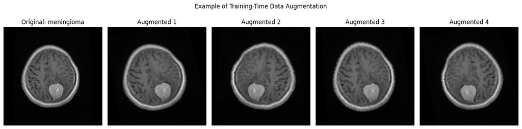

```python
def show_augmented_examples(df_subset, n=4):
    sample = df_subset.sample(n=1, random_state=SEED)
    img_path = sample["filepath"].iloc[0]
    label = sample["label"].iloc[0]

    raw_img = Image.open(img_path).convert("RGB")

    fig, axes = plt.subplots(1, n + 1, figsize=(15, 4))

    axes[0].imshow(raw_img)
    axes[0].set_title(f"Original: {label}")
    axes[0].axis("off")

    for i in range(n):
        aug_img = aug_transform(raw_img)
        aug_img = aug_img.permute(1, 2, 0).numpy()

        # Undo ImageNet normalization for display
        mean = np.array([0.485, 0.456, 0.406])
        std = np.array([0.229, 0.224, 0.225])
        aug_img = std * aug_img + mean
        aug_img = np.clip(aug_img, 0, 1)

        axes[i + 1].imshow(aug_img)
        axes[i + 1].set_title(f"Augmented {i + 1}")
        axes[i + 1].axis("off")

    plt.suptitle("Example of Training-Time Data Augmentation")
    plt.tight_layout()
    plt.show()

show_augmented_examples(train_df, n=4)
```